# Selección de Variables

Alejandro Keymer

# Ejercicios del libro de Faraway

### 1. (Ejercicio 1 cap. 10 pág. 159)

**Use the prostate data with lpsa as the response and the other variables as predictors. Implement the following variable selection methods to determine the “best” model:**

1. Backward elimination

Utilizo la metodoloǵia manual, como aparece en “Faraway”, eliminado los predictores cuya p es mayor. HAy una reducción importante en el valor de $r²$ al eliminar la variable `lbph`. El modelo queda entonces como:

```r
mod <- lm(lpsa ~ . , data = prostate)
summary(mod)
```

```
##
## Call:
## lm(formula = lpsa ~ ., data = prostate)
##
## Residuals:
##     Min      1Q  Median      3Q     Max
## -1.7331 -0.3713 -0.0170  0.4141  1.6381
##
## Coefficients:
##              Estimate Std. Error t value Pr(>|t|)
## (Intercept)  0.669337   1.296387   0.516  0.60693
## lcavol       0.587022   0.087920   6.677 2.11e-09 ***
## lweight      0.454467   0.170012   2.673  0.00896 **
## age         -0.019637   0.011173  -1.758  0.08229 .
## lbph         0.107054   0.058449   1.832  0.07040 .
## svi          0.766157   0.244309   3.136  0.00233 **
## lcp         -0.105474   0.091013  -1.159  0.24964
## gleason      0.045142   0.157465   0.287  0.77503
## pgg45        0.004525   0.004421   1.024  0.30886
## ---
## Signif. codes:  0 '***' 0.001 '**' 0.01 '*' 0.05 '.' 0.1 ' ' 1
##
## Residual standard error: 0.7084 on 88 degrees of freedom
## Multiple R-squared:  0.6548, Adjusted R-squared:  0.6234
## F-statistic: 20.86 on 8 and 88 DF,  p-value: < 2.2e-16
```

```r
mod <- update(mod , .  ~ . - gleason)
summary(mod)
```

```
##
## Call:
## lm(formula = lpsa ~ lcavol + lweight + age + lbph + svi + lcp +
##     pgg45, data = prostate)
##
## Residuals:
##      Min       1Q   Median       3Q      Max
## -1.73117 -0.38137 -0.01728  0.43364  1.63513
##
## Coefficients:
##              Estimate Std. Error t value Pr(>|t|)
## (Intercept)  0.953926   0.829439   1.150  0.25319
## lcavol       0.591615   0.086001   6.879 8.07e-10 ***
## lweight      0.448292   0.167771   2.672  0.00897 **
## age         -0.019336   0.011066  -1.747  0.08402 .
## lbph         0.107671   0.058108   1.853  0.06720 .
## svi          0.757734   0.241282   3.140  0.00229 **
## lcp         -0.104482   0.090478  -1.155  0.25127
## pgg45        0.005318   0.003433   1.549  0.12488
## ---
## Signif. codes:  0 '***' 0.001 '**' 0.01 '*' 0.05 '.' 0.1 ' ' 1
##
## Residual standard error: 0.7048 on 89 degrees of freedom
## Multiple R-squared:  0.6544, Adjusted R-squared:  0.6273
## F-statistic: 24.08 on 7 and 89 DF,  p-value: < 2.2e-16
```

```r
mod <- update(mod , .  ~ . - lcp)
summary(mod)
```

```
##
## Call:
## lm(formula = lpsa ~ lcavol + lweight + age + lbph + svi + pgg45,
##     data = prostate)
##
## Residuals:
##      Min       1Q   Median       3Q      Max
## -1.77711 -0.41708  0.00002  0.40676  1.59681
##
## Coefficients:
##              Estimate Std. Error t value Pr(>|t|)
## (Intercept)  0.980085   0.830665   1.180  0.24116
## lcavol       0.545770   0.076431   7.141 2.31e-10 ***
## lweight      0.449450   0.168078   2.674  0.00890 **
## age         -0.017470   0.010967  -1.593  0.11469
## lbph         0.105755   0.058191   1.817  0.07249 .
## svi          0.641666   0.219757   2.920  0.00442 **
## pgg45        0.003528   0.003068   1.150  0.25331
## ---
## Signif. codes:  0 '***' 0.001 '**' 0.01 '*' 0.05 '.' 0.1 ' ' 1
##
## Residual standard error: 0.7061 on 90 degrees of freedom
## Multiple R-squared:  0.6493, Adjusted R-squared:  0.6259
## F-statistic: 27.77 on 6 and 90 DF,  p-value: < 2.2e-16
```

```r
mod <- update(mod , .  ~ . - pgg45)
summary(mod)
```

```
##
## Call:
## lm(formula = lpsa ~ lcavol + lweight + age + lbph + svi, data = prostate)
##
## Residuals:
##      Min       1Q   Median       3Q      Max
## -1.83505 -0.39396  0.00414  0.46336  1.57888
##
## Coefficients:
##             Estimate Std. Error t value Pr(>|t|)
## (Intercept)  0.95100    0.83175   1.143 0.255882
## lcavol       0.56561    0.07459   7.583 2.77e-11 ***
## lweight      0.42369    0.16687   2.539 0.012814 *
## age         -0.01489    0.01075  -1.385 0.169528
## lbph         0.11184    0.05805   1.927 0.057160 .
## svi          0.72095    0.20902   3.449 0.000854 ***
## ---
## Signif. codes:  0 '***' 0.001 '**' 0.01 '*' 0.05 '.' 0.1 ' ' 1
##
## Residual standard error: 0.7073 on 91 degrees of freedom
## Multiple R-squared:  0.6441, Adjusted R-squared:  0.6245
## F-statistic: 32.94 on 5 and 91 DF,  p-value: < 2.2e-16
```

```r
mod <- update(mod , .  ~ . - age)
summary(mod)
```

```
##
## Call:
## lm(formula = lpsa ~ lcavol + lweight + lbph + svi, data = prostate)
##
## Residuals:
##      Min       1Q   Median       3Q      Max
## -1.82653 -0.42270  0.04362  0.47041  1.48530
##
## Coefficients:
##             Estimate Std. Error t value Pr(>|t|)
## (Intercept)  0.14554    0.59747   0.244  0.80809
## lcavol       0.54960    0.07406   7.422 5.64e-11 ***
## lweight      0.39088    0.16600   2.355  0.02067 *
## lbph         0.09009    0.05617   1.604  0.11213
## svi          0.71174    0.20996   3.390  0.00103 **
## ---
## Signif. codes:  0 '***' 0.001 '**' 0.01 '*' 0.05 '.' 0.1 ' ' 1
##
## Residual standard error: 0.7108 on 92 degrees of freedom
## Multiple R-squared:  0.6366, Adjusted R-squared:  0.6208
## F-statistic: 40.29 on 4 and 92 DF,  p-value: < 2.2e-16
```

```r
mod <- update(mod , .  ~ . - lbph)
summary(mod)
```

```
##
## Call:
## lm(formula = lpsa ~ lcavol + lweight + svi, data = prostate)
##
## Residuals:
##      Min       1Q   Median       3Q      Max
## -1.72964 -0.45764  0.02812  0.46403  1.57013
##
## Coefficients:
##             Estimate Std. Error t value Pr(>|t|)
## (Intercept) -0.26809    0.54350  -0.493  0.62298
## lcavol       0.55164    0.07467   7.388  6.3e-11 ***
## lweight      0.50854    0.15017   3.386  0.00104 **
## svi          0.66616    0.20978   3.176  0.00203 **
## ---
## Signif. codes:  0 '***' 0.001 '**' 0.01 '*' 0.05 '.' 0.1 ' ' 1
##
## Residual standard error: 0.7168 on 93 degrees of freedom
## Multiple R-squared:  0.6264, Adjusted R-squared:  0.6144
## F-statistic: 51.99 on 3 and 93 DF,  p-value: < 2.2e-16
```

2. AIC

```r
rs <-
    regsubsets(lpsa ~ ., data = prostate) %>%
    summary()

n <- dim(prostate)[1]
p <- dim(prostate)[2]


rs$which %>%
    as_tibble() %>%
    mutate(rss = rs$rss,
           aic = n * log(rss/n) + (2 * p)) %>%
    arrange(aic)
```

```
## # A tibble: 8 x 11
##   `(Intercept)` lcavol lweight age   lbph  svi   lcp   gleason pgg45   rss   aic
##   <lgl>         <lgl>  <lgl>   <lgl> <lgl> <lgl> <lgl> <lgl>   <lgl> <dbl> <dbl>
## 1 TRUE          TRUE   TRUE    TRUE  TRUE  TRUE  TRUE  TRUE    TRUE   44.2 -58.3
## 2 TRUE          TRUE   TRUE    TRUE  TRUE  TRUE  TRUE  FALSE   TRUE   44.2 -58.2
## 3 TRUE          TRUE   TRUE    TRUE  TRUE  TRUE  FALSE FALSE   TRUE   44.9 -56.8
## 4 TRUE          TRUE   TRUE    TRUE  TRUE  TRUE  FALSE FALSE   FALSE  45.5 -55.4
## 5 TRUE          TRUE   TRUE    FALSE TRUE  TRUE  FALSE FALSE   FALSE  46.5 -53.4
## 6 TRUE          TRUE   TRUE    FALSE FALSE TRUE  FALSE FALSE   FALSE  47.8 -50.7
## 7 TRUE          TRUE   TRUE    FALSE FALSE FALSE FALSE FALSE   FALSE  53.0 -40.7
## 8 TRUE          TRUE   FALSE   FALSE FALSE FALSE FALSE FALSE   FALSE  58.9 -30.4
```

3. Adjusted R2

Seguimos la misma metodología anterior, pero ordenamos por $r^2$. En este caso el modelo con mayor $r^2$ es:

```r
rs$which %>%
    as_tibble() %>%
    mutate(r2 = rs$adjr2) %>%
    arrange(-r2)
```

```
## # A tibble: 8 x 10
##   `(Intercept)` lcavol lweight age   lbph  svi   lcp   gleason pgg45    r2
##   <lgl>         <lgl>  <lgl>   <lgl> <lgl> <lgl> <lgl> <lgl>   <lgl> <dbl>
## 1 TRUE          TRUE   TRUE    TRUE  TRUE  TRUE  TRUE  FALSE   TRUE  0.627
## 2 TRUE          TRUE   TRUE    TRUE  TRUE  TRUE  FALSE FALSE   TRUE  0.626
## 3 TRUE          TRUE   TRUE    TRUE  TRUE  TRUE  FALSE FALSE   FALSE 0.625
## 4 TRUE          TRUE   TRUE    TRUE  TRUE  TRUE  TRUE  TRUE    TRUE  0.623
## 5 TRUE          TRUE   TRUE    FALSE TRUE  TRUE  FALSE FALSE   FALSE 0.621
## 6 TRUE          TRUE   TRUE    FALSE FALSE TRUE  FALSE FALSE   FALSE 0.614
## 7 TRUE          TRUE   TRUE    FALSE FALSE FALSE FALSE FALSE   FALSE 0.577
## 8 TRUE          TRUE   FALSE   FALSE FALSE FALSE FALSE FALSE   FALSE 0.535
```

4. Mallows Cp

Utilizando el criterio de cp de Mallows:

```r
rs$which %>%
    as_tibble() %>%
    mutate(cp = rs$cp) %>%
    arrange(cp)
```

```
## # A tibble: 8 x 10
##   `(Intercept)` lcavol lweight age   lbph  svi   lcp   gleason pgg45    cp
##   <lgl>         <lgl>  <lgl>   <lgl> <lgl> <lgl> <lgl> <lgl>   <lgl> <dbl>
## 1 TRUE          TRUE   TRUE    FALSE TRUE  TRUE  FALSE FALSE   FALSE  5.63
## 2 TRUE          TRUE   TRUE    TRUE  TRUE  TRUE  FALSE FALSE   FALSE  5.72
## 3 TRUE          TRUE   TRUE    FALSE FALSE TRUE  FALSE FALSE   FALSE  6.22
## 4 TRUE          TRUE   TRUE    TRUE  TRUE  TRUE  FALSE FALSE   TRUE   6.40
## 5 TRUE          TRUE   TRUE    TRUE  TRUE  TRUE  TRUE  FALSE   TRUE   7.08
## 6 TRUE          TRUE   TRUE    TRUE  TRUE  TRUE  TRUE  TRUE    TRUE   9
## 7 TRUE          TRUE   TRUE    FALSE FALSE FALSE FALSE FALSE   FALSE 14.5
## 8 TRUE          TRUE   FALSE   FALSE FALSE FALSE FALSE FALSE   FALSE 24.4
```

### 2. (∗) (Ejercicio 2 cap. 10 pág. 159)

**Using the teengamb dataset with gamble as the response and the other variables as predictors, repeat the work of the first question.**

### 3. (Ejercicio 3 cap. 10 pág. 159)

**Using the divusa dataset with divorce as the response and the other variables as predictors, repeat the work of the first question.**

En primer lugar utilizamos el criterio de eliminación.

El modelo que queda por este criterio es:

```r
mod <- lm(divorce ~ . , data = divusa)
summary(mod)
```

```
##
## Call:
## lm(formula = divorce ~ ., data = divusa)
##
## Residuals:
##     Min      1Q  Median      3Q     Max
## -2.9087 -0.9212 -0.0935  0.7447  3.4689
##
## Coefficients:
##              Estimate Std. Error t value Pr(>|t|)
## (Intercept) 380.14761   99.20371   3.832 0.000274 ***
## year         -0.20312    0.05333  -3.809 0.000297 ***
## unemployed   -0.04933    0.05378  -0.917 0.362171
## femlab        0.80793    0.11487   7.033 1.09e-09 ***
## marriage      0.14977    0.02382   6.287 2.42e-08 ***
## birth        -0.11695    0.01470  -7.957 2.19e-11 ***
## military     -0.04276    0.01372  -3.117 0.002652 **
## ---
## Signif. codes:  0 '***' 0.001 '**' 0.01 '*' 0.05 '.' 0.1 ' ' 1
##
## Residual standard error: 1.513 on 70 degrees of freedom
## Multiple R-squared:  0.9344, Adjusted R-squared:  0.9288
## F-statistic: 166.2 on 6 and 70 DF,  p-value: < 2.2e-16
```

```r
mod <- update(mod , .  ~ . - unemployed)
summary(mod)
```

```
##
## Call:
## lm(formula = divorce ~ year + femlab + marriage + birth + military,
##     data = divusa)
##
## Residuals:
##     Min      1Q  Median      3Q     Max
## -2.7586 -1.0494 -0.0424  0.7201  3.3075
##
## Coefficients:
##              Estimate Std. Error t value Pr(>|t|)
## (Intercept) 405.61670   95.13189   4.264 6.09e-05 ***
## year         -0.21790    0.05078  -4.291 5.52e-05 ***
## femlab        0.85480    0.10276   8.318 4.29e-12 ***
## marriage      0.15934    0.02140   7.447 1.76e-10 ***
## birth        -0.11012    0.01266  -8.700 8.43e-13 ***
## military     -0.04120    0.01360  -3.030  0.00341 **
## ---
## Signif. codes:  0 '***' 0.001 '**' 0.01 '*' 0.05 '.' 0.1 ' ' 1
##
## Residual standard error: 1.511 on 71 degrees of freedom
## Multiple R-squared:  0.9336, Adjusted R-squared:  0.929
## F-statistic: 199.7 on 5 and 71 DF,  p-value: < 2.2e-16
```

```r
mod <- update(mod , .  ~ . - military)
summary(mod)
```

```
##
## Call:
## lm(formula = divorce ~ year + femlab + marriage + birth, data = divusa)
##
## Residuals:
##     Min      1Q  Median      3Q     Max
## -3.3412 -1.0582  0.0435  0.9588  3.7451
##
## Coefficients:
##              Estimate Std. Error t value Pr(>|t|)
## (Intercept) 302.49276   93.74264   3.227  0.00188 **
## year         -0.16189    0.04990  -3.244  0.00179 **
## femlab        0.72607    0.09873   7.354 2.45e-10 ***
## marriage      0.13438    0.02084   6.449 1.13e-08 ***
## birth        -0.11310    0.01332  -8.494 1.84e-12 ***
## ---
## Signif. codes:  0 '***' 0.001 '**' 0.01 '*' 0.05 '.' 0.1 ' ' 1
##
## Residual standard error: 1.595 on 72 degrees of freedom
## Multiple R-squared:  0.925,  Adjusted R-squared:  0.9209
## F-statistic: 222.1 on 4 and 72 DF,  p-value: < 2.2e-16
```

2. AIC

```r
rs <-
    regsubsets(divorce ~ ., data = divusa) %>%
    summary()

n <- dim(divusa)[1]
p <- dim(divusa)[2]


rs$which %>%
    as_tibble() %>%
    mutate(rss = rs$rss,
           aic = n * log(rss/n) + (2 * p)) %>%
    arrange(aic)
```

```
## # A tibble: 6 x 9
##   `(Intercept)` year  unemployed femlab marriage birth military   rss   aic
##   <lgl>         <lgl> <lgl>      <lgl>  <lgl>    <lgl> <lgl>    <dbl> <dbl>
## 1 TRUE          TRUE  TRUE       TRUE   TRUE     TRUE  TRUE      160.  70.4
## 2 TRUE          TRUE  FALSE      TRUE   TRUE     TRUE  TRUE      162.  71.3
## 3 TRUE          TRUE  FALSE      TRUE   TRUE     TRUE  FALSE     183.  80.7
## 4 TRUE          FALSE FALSE      TRUE   TRUE     TRUE  FALSE     210.  91.2
## 5 TRUE          FALSE FALSE      TRUE   FALSE    TRUE  FALSE     304. 120.
## 6 TRUE          FALSE FALSE      TRUE   FALSE    FALSE FALSE     418. 144.
```

3. Adjusted R2

$y_{divorce} = \beta_{year} + \beta_{femlab} + \beta_{marriage} + \beta_{birth} + \beta_{military}$

```r
rs$which %>%
    as_tibble() %>%
    mutate(r2 = rs$adjr2) %>%
    arrange(-r2)
```

```
## # A tibble: 6 x 8
##   `(Intercept)` year  unemployed femlab marriage birth military    r2
##   <lgl>         <lgl> <lgl>      <lgl>  <lgl>    <lgl> <lgl>    <dbl>
## 1 TRUE          TRUE  FALSE      TRUE   TRUE     TRUE  TRUE     0.929
## 2 TRUE          TRUE  TRUE       TRUE   TRUE     TRUE  TRUE     0.929
## 3 TRUE          TRUE  FALSE      TRUE   TRUE     TRUE  FALSE    0.921
## 4 TRUE          FALSE FALSE      TRUE   TRUE     TRUE  FALSE    0.911
## 5 TRUE          FALSE FALSE      TRUE   FALSE    TRUE  FALSE    0.872
## 6 TRUE          FALSE FALSE      TRUE   FALSE    FALSE FALSE    0.827
```

4. Mallows Cp:

$y_{divorce} = \beta_{year} + \beta_{femlab} + \beta_{marriage} + \beta_{birth} + \beta_{military}$

```r
rs$which %>%
    as_tibble() %>%
    mutate(cp = rs$cp) %>%
    arrange(cp)
```

```
## # A tibble: 6 x 8
##   `(Intercept)` year  unemployed femlab marriage birth military     cp
##   <lgl>         <lgl> <lgl>      <lgl>  <lgl>    <lgl> <lgl>     <dbl>
## 1 TRUE          TRUE  FALSE      TRUE   TRUE     TRUE  TRUE       5.84
## 2 TRUE          TRUE  TRUE       TRUE   TRUE     TRUE  TRUE       7
## 3 TRUE          TRUE  FALSE      TRUE   TRUE     TRUE  FALSE     13.0
## 4 TRUE          FALSE FALSE      TRUE   TRUE     TRUE  FALSE     22.7
## 5 TRUE          FALSE FALSE      TRUE   FALSE    TRUE  FALSE     62.0
## 6 TRUE          FALSE FALSE      TRUE   FALSE    FALSE FALSE    110.
```

### 4. (Ejercicio 4 cap. 10 pág. 160)

**Using the trees data, fit a model with log(Volume) as the response and a second-order polynomial (including the interaction term) in Girth and Height. Determine whether the model may be reasonably simplified.**

```r
mod_1 <- lm(log(Volume) ~ Girth * Height, data = trees)
summary(mod_1)
```

```
##
## Call:
## lm(formula = log(Volume) ~ Girth * Height, data = trees)
##
## Residuals:
##      Min       1Q   Median       3Q      Max
## -0.14154 -0.05912 -0.01248  0.05700  0.14502
##
## Coefficients:
##                Estimate Std. Error t value Pr(>|t|)
## (Intercept)  -2.1485424  0.7425484  -2.893  0.00745 **
## Girth         0.3319765  0.0598548   5.546 7.05e-06 ***
## Height        0.0453027  0.0096524   4.693 6.94e-05 ***
## Girth:Height -0.0023796  0.0007594  -3.133  0.00413 **
## ---
## Signif. codes:  0 '***' 0.001 '**' 0.01 '*' 0.05 '.' 0.1 ' ' 1
##
## Residual standard error: 0.08438 on 27 degrees of freedom
## Multiple R-squared:  0.9769, Adjusted R-squared:  0.9743
## F-statistic:   380 on 3 and 27 DF,  p-value: < 2.2e-16
```

```r
n <- dim(trees)[1]
p <- length(coef(mod_1))

mod_2 <- update(mod_1, . ~ . - Girth:Height, data = trees)
summary(mod_2)
```

```
##
## Call:
## lm(formula = log(Volume) ~ Girth + Height, data = trees)
##
## Residuals:
##       Min        1Q    Median        3Q       Max
## -0.177279 -0.086019 -0.009928  0.058914  0.170011
##
## Coefficients:
##             Estimate Std. Error t value Pr(>|t|)
## (Intercept) 0.102585   0.215315   0.476    0.637
## Girth       0.145290   0.006587  22.057  < 2e-16 ***
## Height      0.016385   0.003244   5.051 2.41e-05 ***
## ---
## Signif. codes:  0 '***' 0.001 '**' 0.01 '*' 0.05 '.' 0.1 ' ' 1
##
## Residual standard error: 0.09676 on 28 degrees of freedom
## Multiple R-squared:  0.9684, Adjusted R-squared:  0.9662
## F-statistic: 429.7 on 2 and 28 DF,  p-value: < 2.2e-16
```

Si miramos otros parámetros, como el AIC y el CP de Mallows, coinciden en que el modelo completa, es decir los dos parámetros mas la interacción entre ellos, siguen siendo la mejor opción de modelado.

```r
rs <-
    regsubsets(log(Volume) ~ Girth * Height, data = trees) %>%
    summary()


rs$which %>%
    as_tibble() %>%
    mutate(cp = rs$cp,
           r2 = rs$adjr2,
           rss = rs$rss,
           aic = n * log(rss/n) + (2 * p)) %>%
    arrange(cp)
```

```
## # A tibble: 3 x 8
##   `(Intercept)` Girth Height `Girth:Height`    cp    r2   rss   aic
##   <lgl>         <lgl> <lgl>  <lgl>          <dbl> <dbl> <dbl> <dbl>
## 1 TRUE          TRUE  TRUE   TRUE             4   0.974 0.192 -150.
## 2 TRUE          TRUE  TRUE   FALSE           11.8 0.966 0.262 -140.
## 3 TRUE          FALSE FALSE  TRUE            32.8 0.947 0.426 -125.
```

### 5. (∗) (Ejercicio 5 cap. 10 pág. 160)

**Fit a linear model to the stackloss data with stack.loss as the predictor and the other variables as predictors. Simplify the model if possible. Check the model for outliers and influential points. Now return to the full model, determine whether there are any outliers or influential points, eliminate them and then repeat the variable selection procedures.**

### 6. (Ejercicio 6 cap. 10 pág. 160)

**Use the seatpos data with hipcenter as the response.**

1. Fit a model with all eight predictors. Comment on the effect of leg length on the response.

```r
mod <- lm(hipcenter ~ ., data = seatpos)
summary(mod)
```

```
##
## Call:
## lm(formula = hipcenter ~ ., data = seatpos)
##
## Residuals:
##     Min      1Q  Median      3Q     Max
## -73.827 -22.833  -3.678  25.017  62.337
##
## Coefficients:
##              Estimate Std. Error t value Pr(>|t|)
## (Intercept) 436.43213  166.57162   2.620   0.0138 *
## Age           0.77572    0.57033   1.360   0.1843
## Weight        0.02631    0.33097   0.080   0.9372
## HtShoes      -2.69241    9.75304  -0.276   0.7845
## Ht            0.60134   10.12987   0.059   0.9531
## Seated        0.53375    3.76189   0.142   0.8882
## Arm          -1.32807    3.90020  -0.341   0.7359
## Thigh        -1.14312    2.66002  -0.430   0.6706
## Leg          -6.43905    4.71386  -1.366   0.1824
## ---
## Signif. codes:  0 '***' 0.001 '**' 0.01 '*' 0.05 '.' 0.1 ' ' 1
##
## Residual standard error: 37.72 on 29 degrees of freedom
## Multiple R-squared:  0.6866, Adjusted R-squared:  0.6001
## F-statistic:  7.94 on 8 and 29 DF,  p-value: 1.306e-05
```

En el modelo completo, el efecto de `leg` se relaciona de manera inversa con `hipcenter`. Por cada unidad de `leg` que aumenta, `hipcenter` disminye en `6.44` unidades.

Esta conclusión no tiene mucho sentido y de hecho si bien el modelo si es significativo, el predictor no es significativo por si sólo.

2. Compute a 95% prediction interval for the mean value of the predictors.

```r
confint(mod)
```

```
##                   2.5 %      97.5 %
## (Intercept)  95.7549162 777.1093403
## Age          -0.3907371   1.9421695
## Weight       -0.6505973   0.7032235
## HtShoes     -22.6396042  17.2547887
## Ht          -20.1165738  21.3192629
## Seated       -7.1601858   8.2276892
## Arm          -9.3048669   6.6487296
## Thigh        -6.5834782   4.2972405
## Leg         -16.0799726   3.2018801
```

Esto confirma lo anterior, ya que el intervalo de `Leg` pasa por el 0, lo que implica que no hay un efecto claro del predictor.

3. Use AIC to select a model. Now interpret the effect of leg length and compute the prediction interval. Compare the conclusions from the two models.

```r
mod_aic <- step(mod, trace = 0)
summary(mod_aic)
```

```
##
## Call:
## lm(formula = hipcenter ~ Age + HtShoes + Leg, data = seatpos)
##
## Residuals:
##     Min      1Q  Median      3Q     Max
## -79.269 -22.770  -4.342  21.853  60.907
##
## Coefficients:
##             Estimate Std. Error t value Pr(>|t|)
## (Intercept) 456.2137   102.8078   4.438 9.09e-05 ***
## Age           0.5998     0.3779   1.587   0.1217
## HtShoes      -2.3023     1.2452  -1.849   0.0732 .
## Leg          -6.8297     4.0693  -1.678   0.1024
## ---
## Signif. codes:  0 '***' 0.001 '**' 0.01 '*' 0.05 '.' 0.1 ' ' 1
##
## Residual standard error: 35.13 on 34 degrees of freedom
## Multiple R-squared:  0.6813, Adjusted R-squared:  0.6531
## F-statistic: 24.22 on 3 and 34 DF,  p-value: 1.437e-08
```

```r
confint(mod_aic)
```

```
##                   2.5 %      97.5 %
## (Intercept) 247.2830805 665.1442272
## Age          -0.1681983   1.3678637
## HtShoes      -4.8328023   0.2282913
## Leg         -15.0994772   1.4399850
```

Si bien el intervalo es algo mas pequeño, aun pasa por el 0.

### 7. (∗) (Ejercicio 8 cap. 10 pág. 160)

**Use the odor data with odor as the response.**

1. Fit a second-order response surcare model chic contains all quadratic and cross-product terms of the three predictors. Explicitly include all nine terms in your model statement. You will need to “protect” these terms using the I() function. Show the regression summary.
2. Use the backward elimination method with a cut-off of 5% to select a smaller model.
3. Use the step method to select a model using AIC. Using this selected model determine the optimal values of the predictors to minimize odor.
4. Use the polym function to fit a second-order orthogonal polynomial regression model to the response using the three predictors. Confirm that the fit is identical to (a).
5. Apply the step procedure to this last model. What terms are considered for elimination? What model was selected? Compare the outcome with (c).

### 8. (Ejercicio 1 cap. 11 pág. 180)

**Using the seatpos data, perform a PCR analysis with hipcenter as the response and HtShoes, Ht, Seated, Arm, Thigh and Leg as predictors. Select an appropriate number of components and give an interpretation to those you choose. Add Age and Weight as predictors and repeat the analysis. Use both models to predict the response for predictors taking these values:**

```r
rmse <- function(x,y) sqrt(mean((x-y)^2))

new_dt <-
tribble(
~Age, ~Weight,  ~HtShoes, ~Ht, ~Seated, ~Arm, ~Thigh, ~Leg,
64.800, 263.700, 181.080, 178.560, 91.440, 35.640, 40.950, 38.790)
```

Primero miramos que ocurre con un PCA de los predictores. En el caso de 6 predictores, el screeplot tiene un codo pronunciado entre las dos primeras dimensiones. En el caso de 8 predictores, hay codos en 2, 3 y 4 dimensiones. Las dos primeras tienen valores propios > 1.

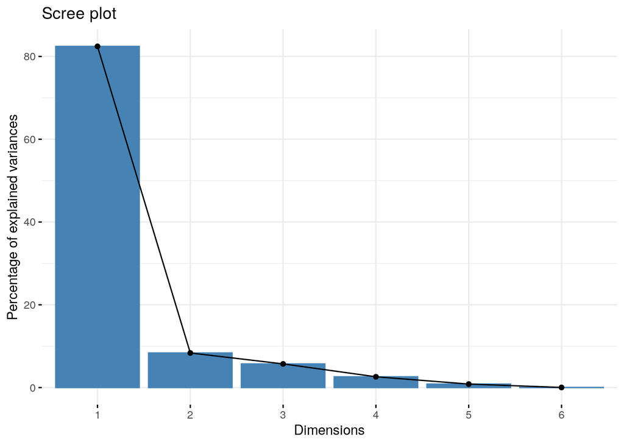

```r
pca_1 <-
    seatpos %>%
    select(HtShoes, Ht, Seated, Arm, Thigh, Leg) %>%
    PCA(graph = F)

fviz_screeplot(pca_1)
```

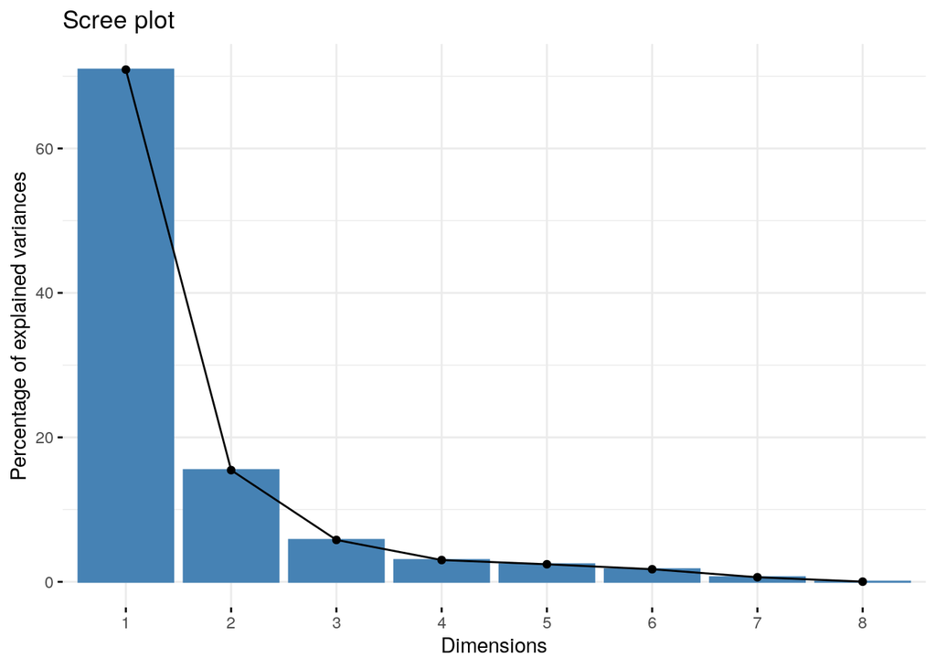

```r
pca_2 <-
    seatpos %>%
    select(HtShoes, Ht, Seated, Arm, Thigh, Leg, Age, Weight) %>%
    PCA(graph = F)

fviz_screeplot(pca_2)
```

```r
pca_2$eig
```

```
##         eigenvalue percentage of variance cumulative percentage of variance
## comp 1 5.673185670            70.91482088                          70.91482
## comp 2 1.236786010            15.45982512                          86.37465
## comp 3 0.463743442             5.79679303                          92.17144
## comp 4 0.240958348             3.01197935                          95.18342
## comp 5 0.194219564             2.42774455                          97.61116
## comp 6 0.139174200             1.73967750                          99.35084
## comp 7 0.050344527             0.62930659                          99.98015
## comp 8 0.001588239             0.01985298                         100.00000
```

Al realizar el modelo con la función `pcr`, se confirma lo visto en el screeplot inicial, y es que con 1 sola dimensión se explica gran parte de la variabilidad de la muestra. Hacemos la predicción con 1 sola dimensión. Esto tiene sentido en la medida de que todos los predictores del modelo parecen tener una alta correlación, ya que son todos algún tipo de medida

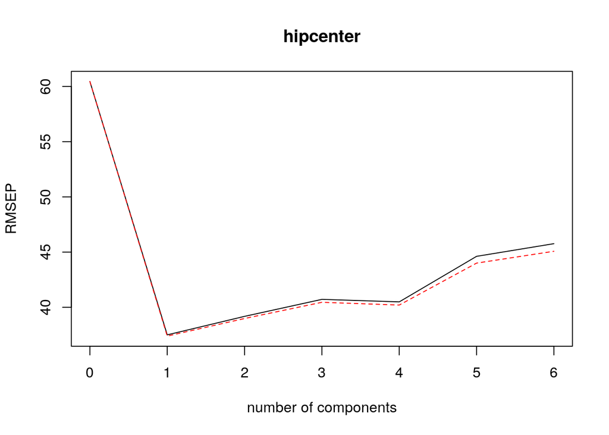

```r
mod_1 <- pcr(hipcenter ~ HtShoes + Ht + Seated + Arm + Thigh + Leg, data = seatpos, validation = "CV")

plot(RMSEP(mod_1))
```

```r
ypred <- predict(mod_1, new_dt, ncomp=1)

rmse(ypred, seatpos$hipcenter)
```

```
## [1] 71.27995
```

EN el caso del modelo con 8 predictores, según el gráfico de RMSEP, la solución mas optima es la de 3 dimensiones. Utilizamos esta información para la predicción. Esto tiene sentido ya que la edad y el peso, no deben cor relacionar tanto entre si, no con las otras variables de medida.

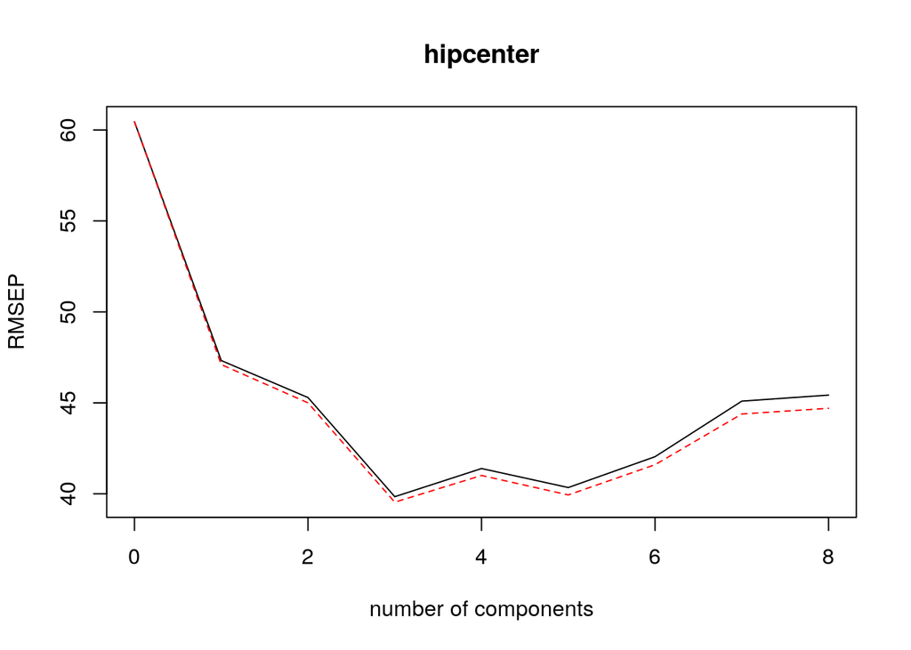

```r
mod_2 <- pcr(hipcenter ~ HtShoes + Ht + Seated + Arm + Thigh + Leg + Age + Weight, data = seatpos, validation = "CV")
plot(RMSEP(mod_2))
```

```r
ypred <- predict(mod_2, new_dt, ncomp=3)

rmse(ypred, seatpos$hipcenter)
```

```
## [1] 62.80201
```

### 9. (Ejercicio 2 cap. 11 pág. 181)

**Fit a PLS model to the seatpos data with hipcenter as the response and all other variables as predictors. Take care to select an appropriate number of components. Use the model to predict the response at the values of the predictors specified in the first question.**

En este caso, el modelo mas optimo de PLS es el que utiliza 3 componentes.

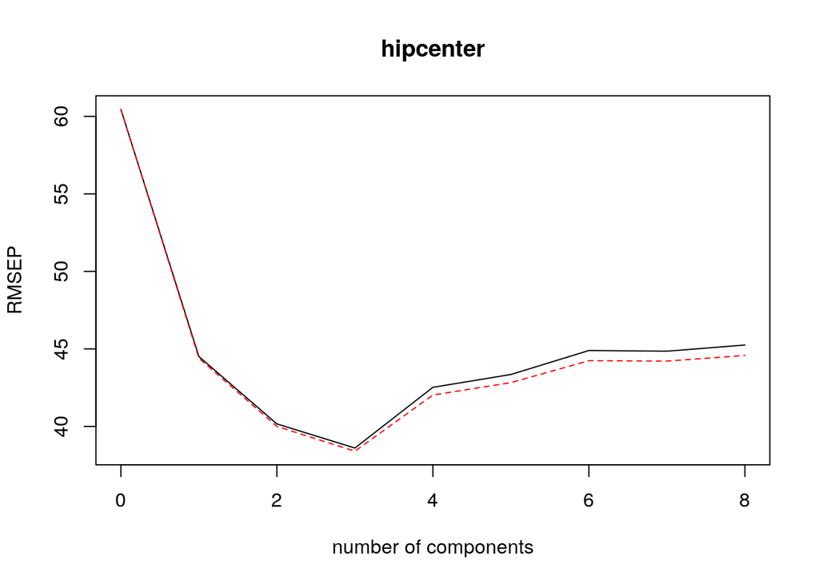

```r
mod_pls <- plsr(hipcenter ~ ., data = seatpos, validation = "CV")

plot(RMSEP(mod_pls))
```

```r
ypred <- predict(mod_pls, new_dt, ncomp = 3)

rmse(ypred, seatpos$hipcenter)
```

```
## [1] 62.49279
```

### 10. (Ejercicio 3 cap. 11 pág. 181)

**Fit a ridge regression model to the seatpos data with hipcenter as the response and all other variables as predictors. Take care to select an appropriate amount of shrinkage. Use the model to predict the response at the values of the predictors specified in the first question.**

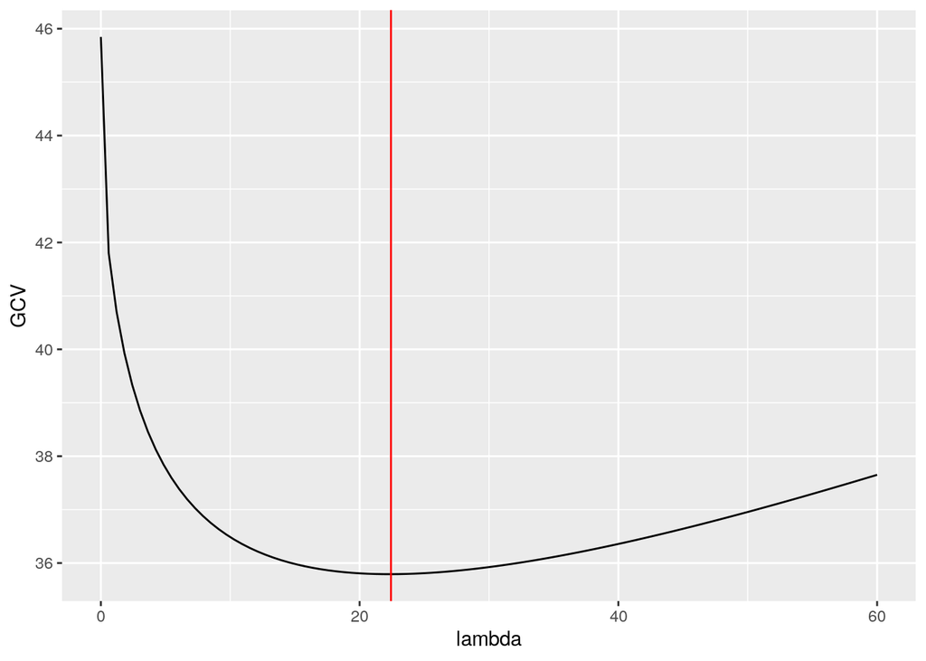

```r
# creamos el modelo con una secuencia de lambda experimental
rg_mod <- MASS::lm.ridge(hipcenter ~ ., data = seatpos, lambda = seq(0, 60, len=100))

lbd <-
    tidy(rg_mod) %>%
    distinct(lambda, GCV) %>%
    rowid_to_column() %>%
    top_n(1, -GCV)

# plot de los GCV
tidy(rg_mod) %>%
    ggplot(aes(lambda, GCV)) +
    geom_line() +
    geom_vline(xintercept = lbd$lambda, color = "red")
```

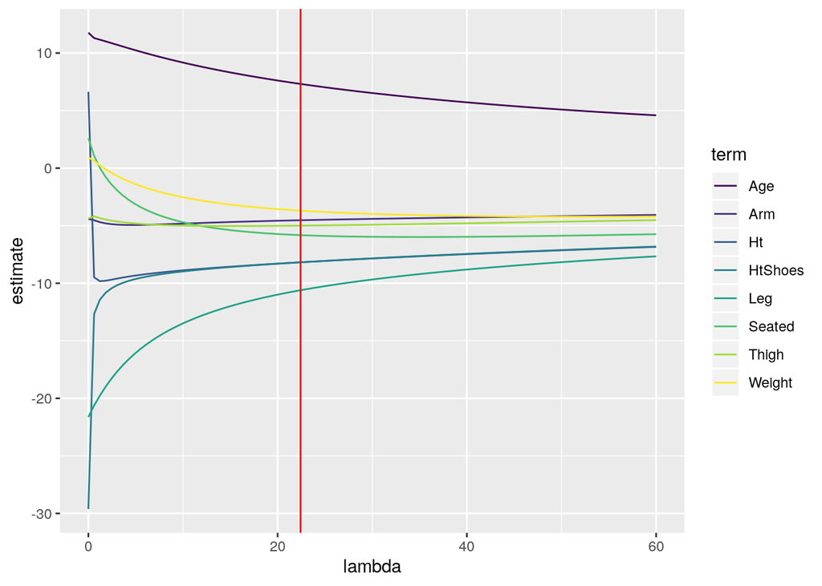

```r
tidy(rg_mod) %>%
    ggplot(aes(lambda, estimate, color = term)) +
    geom_line() +
    geom_vline(xintercept = lbd$lambda, color = "red") +
    scale_colour_viridis_d()
```

```r
# hacemos la prediccion con el valor de lambda que minimiza GCV

ypred <- cbind(1, as.matrix(select(seatpos, -hipcenter))) %*% coef(rg_mod)[lbd$rowid,]


# rendimiento del modelo
rmse(ypred, seatpos$hipcenter)
```

```
## [1] 34.13038
```

### 11. (Ejercicio 4 cap. 11 pág. 181)

**Take the fat data, and use the percentage of body fat, siri, as the response and the other variables, except brozek and density as potential predictors. Remove every tenth observation from the data for use as a test sample. Use the remaining data as a training sample building the following models:**

```r
n <- dim(fat)[1]

test_fat <-
    fat %>%
    select(-brozek, -density) %>%
    slice(seq(0,n, by = 10))

train_fat <-
    fat %>%
    select(-brozek, -density) %>%
    slice(-seq(0,n, by = 10))
```

1. Linear regression with all predictors

Realizamos el modelo lineal con todos los predictores

```r
mod_a <- lm(siri ~ ., train_fat)
summary(mod_a)
```

```
##
## Call:
## lm(formula = siri ~ ., data = train_fat)
##
## Residuals:
##     Min      1Q  Median      3Q     Max
## -5.8314 -0.6722  0.1828  0.9150  6.6619
##
## Coefficients:
##               Estimate Std. Error t value Pr(>|t|)
## (Intercept) -12.591885   6.448868  -1.953 0.052193 .
## age           0.007978   0.012320   0.648 0.517983
## weight        0.362999   0.023314  15.570  < 2e-16 ***
## height        0.049026   0.040315   1.216 0.225315
## adipos       -0.514032   0.114074  -4.506 1.09e-05 ***
## free         -0.564773   0.014889 -37.933  < 2e-16 ***
## neck          0.016525   0.089863   0.184 0.854272
## chest         0.120219   0.039590   3.037 0.002694 **
## abdom         0.140108   0.042186   3.321 0.001056 **
## hip           0.006197   0.056101   0.110 0.912148
## thigh         0.195057   0.054460   3.582 0.000424 ***
## knee          0.106637   0.093534   1.140 0.255542
## ankle         0.125118   0.081303   1.539 0.125325
## biceps        0.096199   0.064656   1.488 0.138278
## forearm       0.230775   0.073332   3.147 0.001888 **
## wrist         0.139279   0.206804   0.673 0.501378
## ---
## Signif. codes:  0 '***' 0.001 '**' 0.01 '*' 0.05 '.' 0.1 ' ' 1
##
## Residual standard error: 1.55 on 211 degrees of freedom
## Multiple R-squared:  0.9692, Adjusted R-squared:  0.967
## F-statistic: 442.5 on 15 and 211 DF,  p-value: < 2.2e-16
```

```r
# rednimiento del modelo
rmse(mod_a$fitted.values, train_fat$siri)
```

```
## [1] 1.494315
```

```r
# rendimienot de la predicción
ypred_lm <- predict(mod_a, test_fat)
rmse(ypred_lm, test_fat$siri)
```

```
## [1] 1.131529
```

2. Linear regression with variables selected using AIC

```r
mod_b <- step(lm(siri ~ ., train_fat), trace = 0)
summary(mod_b)
```

```
##
## Call:
## lm(formula = siri ~ weight + adipos + free + chest + abdom +
##     thigh + knee + ankle + biceps + forearm, data = train_fat)
##
## Residuals:
##     Min      1Q  Median      3Q     Max
## -5.7926 -0.6839  0.2371  0.8824  6.8655
##
## Coefficients:
##             Estimate Std. Error t value Pr(>|t|)
## (Intercept) -7.24766    3.94171  -1.839 0.067331 .
## weight       0.36973    0.01994  18.546  < 2e-16 ***
## adipos      -0.57022    0.09459  -6.028 7.09e-09 ***
## free        -0.55965    0.01400 -39.978  < 2e-16 ***
## chest        0.12099    0.03809   3.176 0.001709 **
## abdom        0.15824    0.03908   4.049 7.18e-05 ***
## thigh        0.16140    0.04551   3.546 0.000479 ***
## knee         0.12767    0.08749   1.459 0.145947
## ankle        0.13817    0.07858   1.758 0.080106 .
## biceps       0.11222    0.06317   1.777 0.077055 .
## forearm      0.24281    0.06990   3.474 0.000620 ***
## ---
## Signif. codes:  0 '***' 0.001 '**' 0.01 '*' 0.05 '.' 0.1 ' ' 1
##
## Residual standard error: 1.544 on 216 degrees of freedom
## Multiple R-squared:  0.9687, Adjusted R-squared:  0.9673
## F-statistic: 668.6 on 10 and 216 DF,  p-value: < 2.2e-16
```

```r
# rendimiento del modelo
rmse(mod_b$fitted.values, train_fat$siri)
```

```
## [1] 1.505982
```

```r
# prediccion
ypred_aic <- predict(mod_b, test_fat)
rmse(ypred_aic, test_fat$siri)
```

```
## [1] 1.12202
```

3. Principal component regression

Hay varias opciones dependienta del criterio de selección de componentes. Si seguimos el criterio, utilizando el plot de RMSEP, el mejor modelo es el que utiliza 7 componentes.

```r
mod_pca <-
    train_fat %>%
    select(-siri) %>%
    PCA(graph = F)

summary(mod_pca)
```

```
##
## Call:
## PCA(X = ., graph = F)
##
##
## Eigenvalues
##                        Dim.1   Dim.2   Dim.3   Dim.4   Dim.5   Dim.6   Dim.7
## Variance               9.434   1.541   1.086   0.687   0.598   0.367   0.327
## % of var.             62.896  10.276   7.242   4.578   3.988   2.445   2.177
## Cumulative % of var.  62.896  73.172  80.414  84.992  88.980  91.425  93.602
##                        Dim.8   Dim.9  Dim.10  Dim.11  Dim.12  Dim.13  Dim.14
## Variance               0.273   0.198   0.182   0.128   0.076   0.046   0.039
## % of var.              1.817   1.318   1.214   0.853   0.510   0.308   0.259
## Cumulative % of var.  95.419  96.738  97.951  98.804  99.314  99.622  99.881
##                       Dim.15
## Variance               0.018
## % of var.              0.119
## Cumulative % of var. 100.000
##
## Individuals (the 10 first)
##             Dist    Dim.1    ctr   cos2    Dim.2    ctr   cos2    Dim.3    ctr
## 1       |  3.051 | -2.242  0.235  0.540 | -0.783  0.175  0.066 | -1.772  1.274
## 2       |  2.654 | -0.697  0.023  0.069 | -2.247  1.443  0.717 | -0.480  0.093
## 3       |  4.231 | -2.556  0.305  0.365 | -0.168  0.008  0.002 | -2.546  2.630
## 4       |  2.193 |  0.176  0.001  0.006 | -1.750  0.875  0.637 | -0.630  0.161
## 5       |  3.102 |  0.191  0.002  0.004 | -0.993  0.282  0.103 | -1.663  1.121
## 6       |  4.123 |  3.228  0.487  0.613 | -2.368  1.603  0.330 | -0.646  0.169
## 7       |  1.892 | -0.317  0.005  0.028 | -0.699  0.140  0.137 | -1.259  0.642
## 8       |  2.137 | -0.083  0.000  0.001 | -1.768  0.893  0.685 | -0.192  0.015
## 9       |  3.524 |  1.278  0.076  0.132 | -2.797  2.237  0.630 | -0.464  0.087
## 10      |  3.017 |  0.833  0.032  0.076 | -2.706  2.093  0.804 |  0.152  0.009
##           cos2
## 1        0.337 |
## 2        0.033 |
## 3        0.362 |
## 4        0.082 |
## 5        0.287 |
## 6        0.025 |
## 7        0.442 |
## 8        0.008 |
## 9        0.017 |
## 10       0.003 |
##
## Variables (the 10 first)
##            Dim.1    ctr   cos2    Dim.2    ctr   cos2    Dim.3    ctr   cos2
## age     |  0.036  0.014  0.001 |  0.731 34.692  0.535 |  0.635 37.111  0.403 |
## weight  |  0.981 10.197  0.962 | -0.012  0.010  0.000 | -0.030  0.083  0.001 |
## height  |  0.275  0.801  0.076 | -0.664 28.631  0.441 |  0.529 25.725  0.279 |
## adipos  |  0.906  8.707  0.821 |  0.301  5.866  0.090 | -0.177  2.896  0.031 |
## free    |  0.787  6.571  0.620 | -0.434 12.238  0.189 |  0.083  0.641  0.007 |
## neck    |  0.865  7.937  0.749 |  0.070  0.320  0.005 |  0.161  2.380  0.026 |
## chest   |  0.902  8.618  0.813 |  0.248  3.991  0.062 |  0.014  0.018  0.000 |
## abdom   |  0.888  8.358  0.788 |  0.339  7.452  0.115 | -0.041  0.157  0.002 |
## hip     |  0.929  9.156  0.864 |  0.066  0.285  0.004 | -0.201  3.705  0.040 |
## thigh   |  0.877  8.149  0.769 | -0.047  0.143  0.002 | -0.343 10.805  0.117 |
```

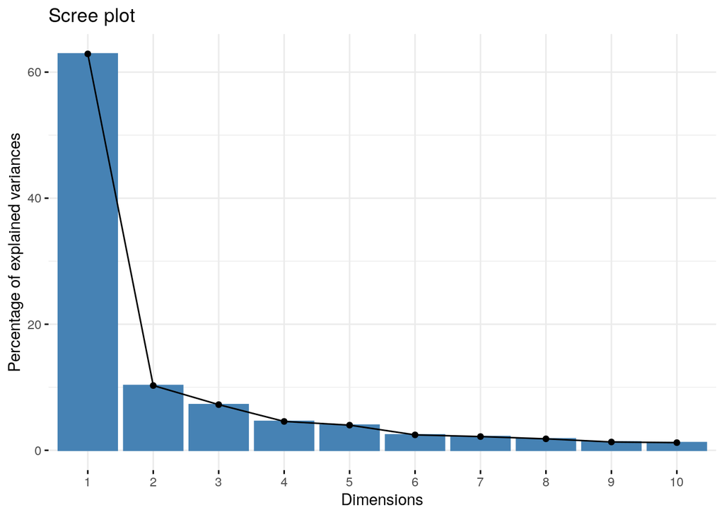

```r
fviz_screeplot(mod_pca)
```

```r
mod_c <- pcr(siri ~ ., data = train_fat, validation = "CV", ncomp = 8)
summary(mod_c)
```

```
## Data:    X dimension: 227 15
##  Y dimension: 227 1
## Fit method: svdpc
## Number of components considered: 8
##
## VALIDATION: RMSEP
## Cross-validated using 10 random segments.
##        (Intercept)  1 comps  2 comps  3 comps  4 comps  5 comps  6 comps
## CV           8.551    7.163    4.992    2.191    1.868    1.872    1.786
## adjCV        8.551    7.160    4.988    2.184    1.822    1.862    1.775
##        7 comps  8 comps
## CV       1.774    1.926
## adjCV    1.760    1.910
##
## TRAINING: % variance explained
##       1 comps  2 comps  3 comps  4 comps  5 comps  6 comps  7 comps  8 comps
## X       79.61    91.87    97.12    97.88    98.58    98.95    99.23    99.43
## siri    30.28    67.12    93.97    95.71    95.85    96.29    96.42    96.42
```

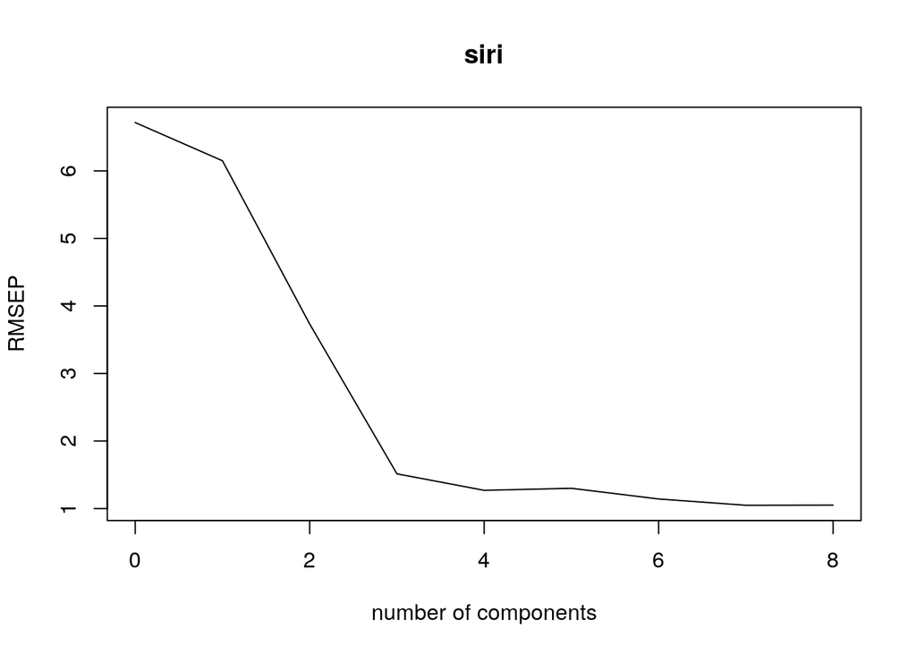

```r
RMSEP(mod_c, newdata = test_fat) %>%
    plot()
```

```r
# componentes
# rendimiento del modelo
rmse(mod_c$fitted.values, train_fat$siri)
```

```
## [1] 3.404555
```

```r
# prediccion con 7 componentes
ypred_pcr <- predict(mod_c, test_fat, ncomp = 7)
rmse(ypred_pcr, test_fat$siri)
```

```
## [1] 1.048851
```

4. Partial least squares

En este caso, como es esperable, son necesarias menos dimensiones. El mejor modelo según RMSEP es el que utiliza 4 dimensiones.

```r
mod_d <- plsr(siri ~ ., data = train_fat, validation = "CV", ncomp = 10)
summary(mod_d)
```

```
## Data:    X dimension: 227 15
##  Y dimension: 227 1
## Fit method: kernelpls
## Number of components considered: 10
##
## VALIDATION: RMSEP
## Cross-validated using 10 random segments.
##        (Intercept)  1 comps  2 comps  3 comps  4 comps  5 comps  6 comps
## CV           8.551    6.459    3.095    2.043    1.810    1.948    2.004
## adjCV        8.551    6.453    3.091    2.038    1.799    1.923    1.969
##        7 comps  8 comps  9 comps  10 comps
## CV       2.068    2.183    2.585     3.085
## adjCV    2.031    2.136    2.507     2.973
##
## TRAINING: % variance explained
##       1 comps  2 comps  3 comps  4 comps  5 comps  6 comps  7 comps  8 comps
## X       77.45    90.88    97.09    97.84    98.21    98.48    99.01    99.26
## siri    45.56    87.73    94.80    96.41    96.69    96.83    96.87    96.90
##       9 comps  10 comps
## X       99.39     99.50
## siri    96.92     96.92
```

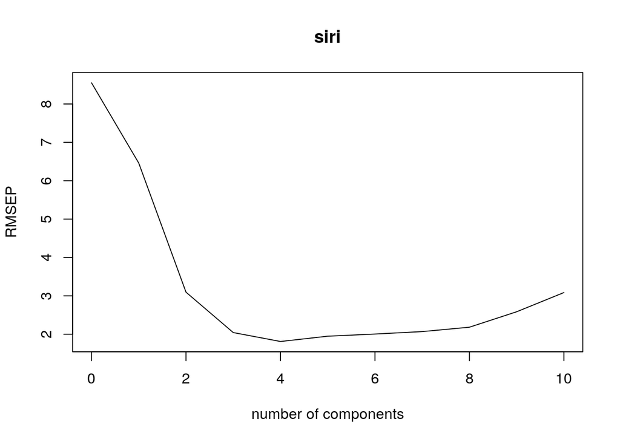

```r
plot(RMSEP(mod_d, estimate="CV"))
```

```r
# rendimiento del modelo
rmse(mod_d$fitted.values, train_fat$siri)
```

```
## [1] 2.615538
```

```r
# predicciones
ypred_pls <- predict(mod_d, test_fat, ncomp = 4)
rmse(ypred_pls, test_fat$siri)
```

```
## [1] 1.12449
```

5. Ridge regression

comenzamos con un modelo y una secuencia de lambda experimental para obtener el valor de lambda que minimiza el GCV

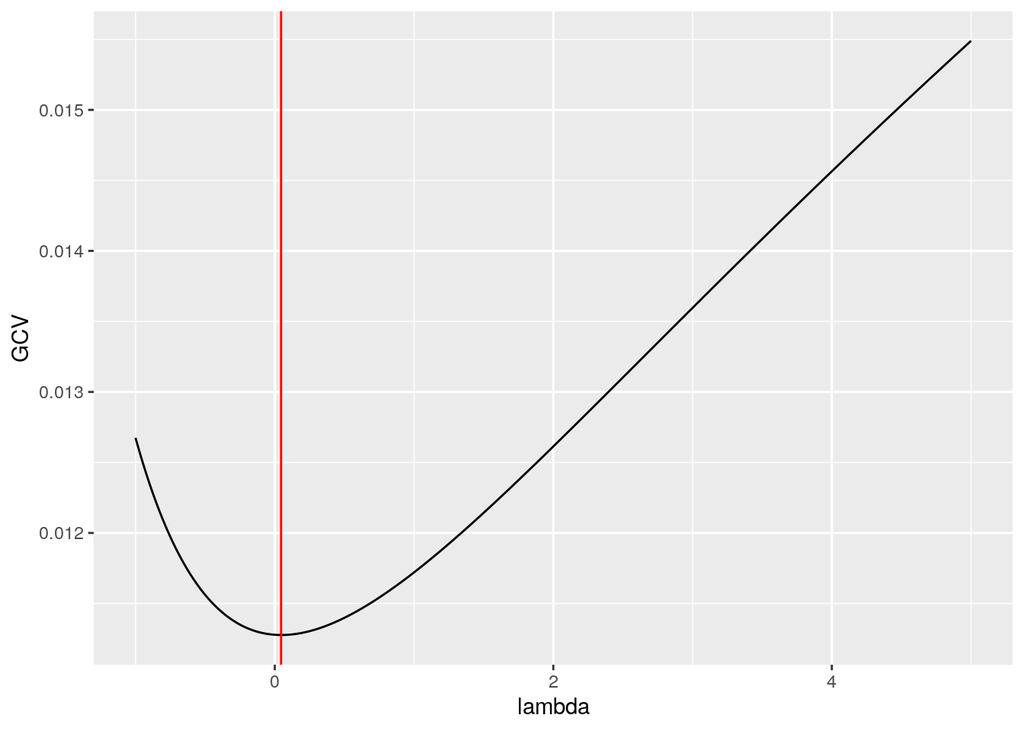

```r
mod_e <- MASS::lm.ridge(siri ~ ., data = train_fat, lambda = seq(-1, 5, len=1000))

lbd <-
    tidy(mod_e) %>%
    distinct(lambda, GCV) %>%
    rowid_to_column() %>%
    top_n(1, -GCV)

# plot de los GCV
tidy(mod_e) %>%
    ggplot(aes(lambda, GCV)) +
    geom_line() +
    geom_vline(xintercept = lbd$lambda, color = "red")
```

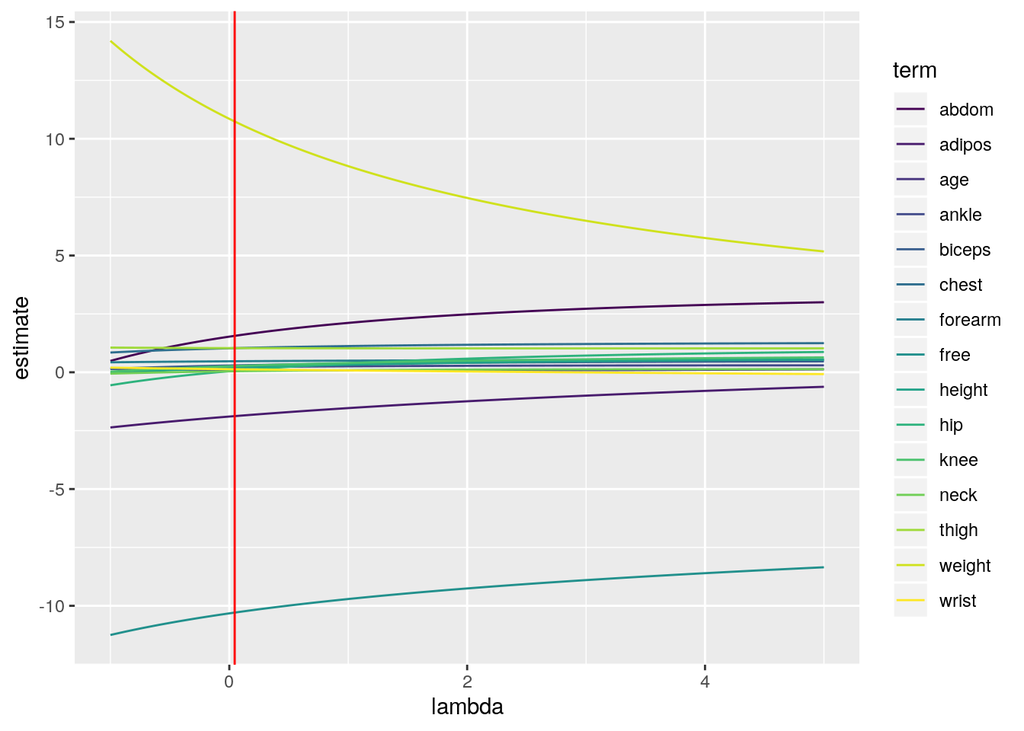

```r
tidy(mod_e) %>%
    ggplot(aes(lambda, estimate, color = term)) +
    geom_line() +
    geom_vline(xintercept = lbd$lambda, color = "red") +
    scale_colour_viridis_d()
```

```r
# rendimiento del modelo
ypred <- cbind(1, as.matrix(select(train_fat, -siri))) %*% coef(mod_e)[lbd$rowid,]
rmse(ypred, train_fat$siri)
```

```
## [1] 1.494415
```

```r
# rendimiento de la prediccion
ypred_rg <- cbind(1, as.matrix(select(test_fat, -siri))) %*% coef(mod_e)[lbd$rowid,]
rmse(ypred_rg, test_fat$siri)
```

```
## [1] 1.128205
```

Use the models you find to predict the response in the test sample. Make a report on the performances of the models.

```r
tribble(
    ~model, ~rmse,
'LM', rmse(ypred_lm, test_fat$siri),
'AIC', rmse(ypred_aic, test_fat$siri),
'PCR', rmse(ypred_pcr, test_fat$siri),
'PLS', rmse(ypred_pls, test_fat$siri),
'Ridge', rmse(ypred_rg, test_fat$siri))
```

```
## # A tibble: 5 x 2
##   model  rmse
##   <chr> <dbl>
## 1 LM     1.13
## 2 AIC    1.12
## 3 PCR    1.05
## 4 PLS    1.12
## 5 Ridge  1.13
```

El mejor modelo es el que utiliza una reducción de dimensiones con PCA, utilizando 7 dimensiones.

### 12. (Ejercicio 5 cap. 11 pág. 181)

**Some near infrared spectra on 60 samples of gasoline and corresponding octane numbers can be found by data(gasoline, package=“pls”). Compute the mean value for each frequency and predict the response for the best model using the five different methods from Question 4.**

```r
# No he podido comprender como construir el modelo en esta pregunta!
```

### 13. (∗) (Ejercicio 6 cap. 11 pág. 181)

**The dataset kanga contains data on the skulls of historical kangaroo specimens.**

```r
df <-
    kanga %>%
    na.omit()
```

1. Compute a PCA on the 18 skull measurements. You will need to exclude observations with missing values. What percentage of variation is explained by the first principal component?

```r
# PCA si escalado
mod_pca <-
    df %>%
    select(basilar.length:ramus.height) %>%
    PCA(graph= F, scale.unit = F)

# porcetnaje de varianza explicado por el 1er comp.
mod_pca$eig[1,2]
```

```
## [1] 90.02572
```

2. Provide the loadings for the first principal component. What variables are prominent?

```r
# FactoMineR PCA no devuelve loadings, hay que calucularlos con las coordenadas ppales.
data.frame(loadings = mod_pca$var$coord[, 1] / sqrt(mod_pca$eig[1])) %>%
    rownames_to_column("variable") %>%
    arrange(-abs(loadings))
```

```
##                variable     loadings
## 1        basilar.length  0.484068280
## 2  occipitonasal.length  0.456296136
## 3       mandible.length  0.435981938
## 4         palate.length  0.366214204
## 5          nasal.length  0.248098913
## 6          ramus.height  0.209071437
## 7       zygomatic.width  0.206697648
## 8       occipital.depth  0.178177037
## 9        lacrymal.width  0.118936859
## 10       .rostral.width  0.106458931
## 11         palate.width  0.084357568
## 12          crest.width -0.081968043
## 13          nasal.width  0.074647492
## 14      squamosal.depth  0.063661339
## 15       mandible.depth  0.058322138
## 16       mandible.width  0.029996792
## 17        orbital.width  0.014288869
## 18      foramina.length  0.009941189
```

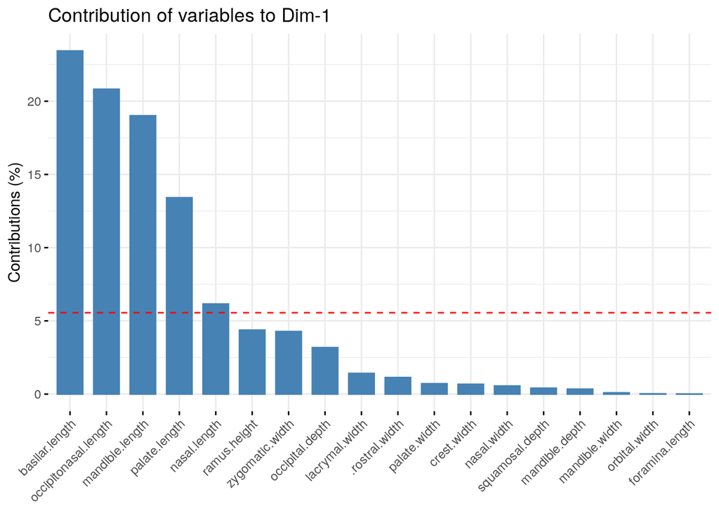

```r
fviz_contrib(mod_pca, choice = "var")
```

El plot de `contribuciones` permite ver el peso de cada variable en la dimension 1.

3. Repeat the PCA but with the variables all scaled to the same standard deviation. How do the percentage of variation explained and the first principal component differ from those found in the previous PCA?

```r
# PCA con escalado
mod_pca_s <-
    df %>%
    select(basilar.length:ramus.height) %>%
    PCA(graph= F, scale.unit = T)

# porcetnaje de varianza explicado por el 1er comp.
mod_pca_s$eig[1,2]
```

```
## [1] 69.31018
```

```r
# FactoMineR PCA no devuelve loadings, hay que calucularlos con las coordenadas ppales.
data.frame(loadings = mod_pca_s$var$coord[, 1] / sqrt(mod_pca_s$eig[1])) %>%
    rownames_to_column("variable") %>%
    arrange(-abs(loadings))
```

```
##                variable    loadings
## 1       mandible.length  0.27876043
## 2        basilar.length  0.27663672
## 3         palate.length  0.27537523
## 4       occipital.depth  0.27101120
## 5  occipitonasal.length  0.26669384
## 6        lacrymal.width  0.26636218
## 7          ramus.height  0.25998273
## 8       zygomatic.width  0.25791527
## 9        .rostral.width  0.25779463
## 10       mandible.depth  0.23957437
## 11      squamosal.depth  0.23883025
## 12         palate.width  0.23411769
## 13         nasal.length  0.23005097
## 14          nasal.width  0.22715310
## 15       mandible.width  0.20978820
## 16          crest.width -0.16457085
## 17        orbital.width  0.07450619
## 18      foramina.length  0.05854653
```

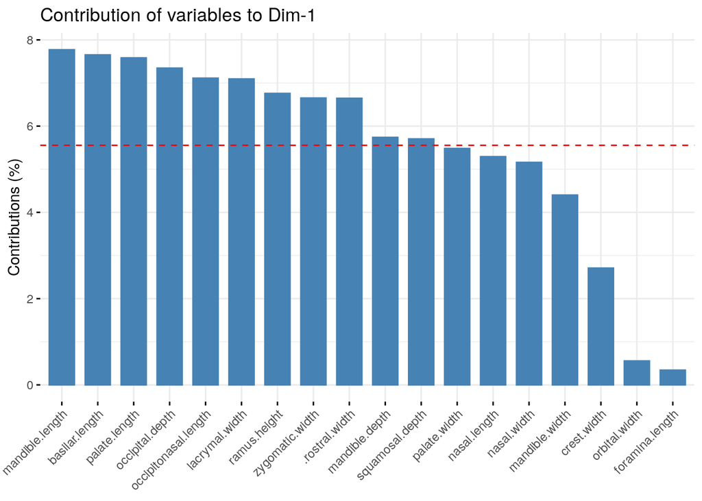

```r
fviz_contrib(mod_pca_s, choice = "var")
```

Al escalar las variables, el porcentaje de varianza explicada por el 1er componente baja a 69.3%

4. Give an interpretation of the second principal component.

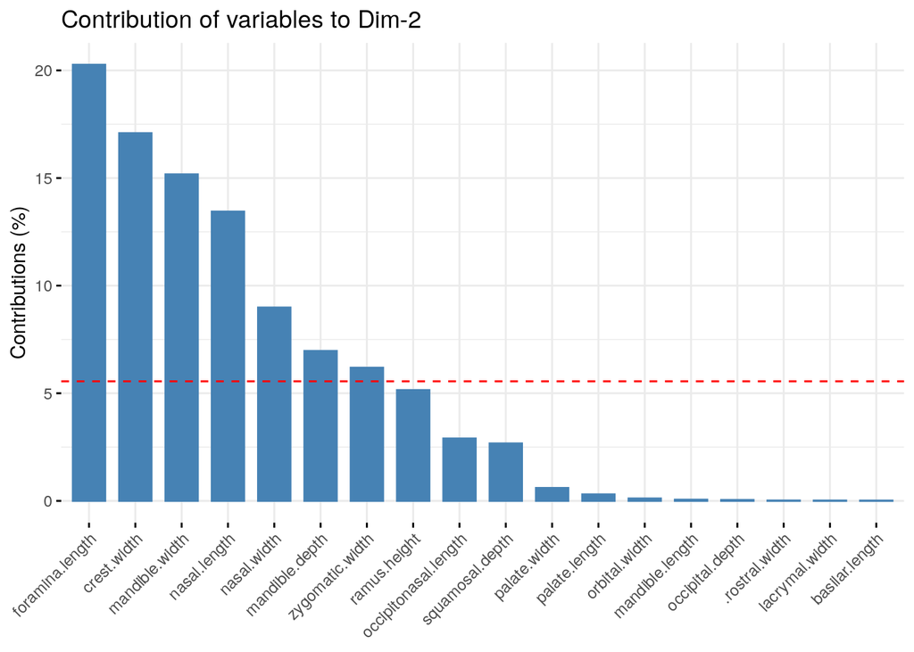

```r
fviz_contrib(mod_pca_s, choice = "var", axes = 2)
```

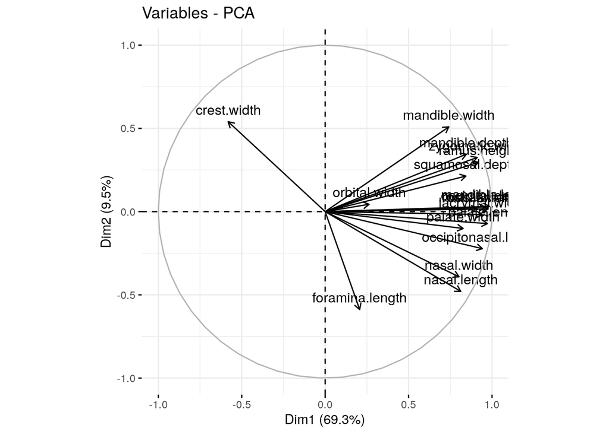

```r
# plot de variables en la dimension 1 y 2
fviz_pca_var(mod_pca_s)
```

El componente 2 esta caracterizado por las variables `foramina.lenght`, `crest.width`, `mandible.width`, `nasal.length`, `nasal.width`, `mandible.depth` y `zygomatic.width`

5. Compute the Mahalanobis distances and plot appropriately to check for outliers.

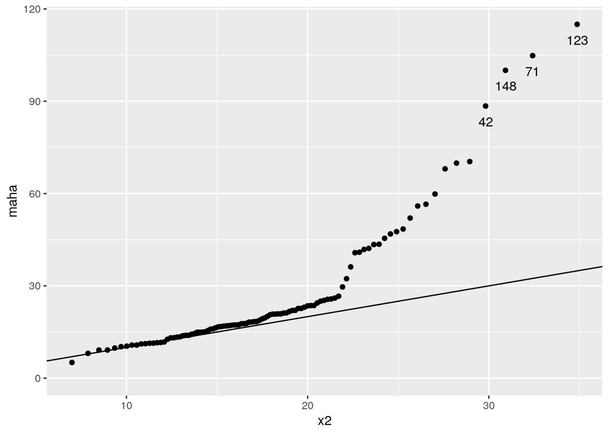

```r
rob_mat <-
    df %>%
    dplyr::select(basilar.length:ramus.height) %>%
    MASS::cov.rob()


md <- mahalanobis(select(df, basilar.length:ramus.height), center=rob_mat$center, cov=rob_mat$cov)

n <- nrow(select(df, basilar.length:ramus.height)) ; p<-ncol(select(df, basilar.length:ramus.height))


data.frame(
    maha = sort(md),
    x2 = qchisq(1:n/(n+1), p)
    ) %>%
    rownames_to_column() %>%
    mutate(diff = abs(maha - x2)) %>%
    ggplot(aes(x2, maha)) +
    geom_point() +
    geom_abline(slope = 1, intercept= 0)+
    geom_text(aes(label = ifelse(diff>50,rowname,NA)), nudge_y = -5)
```

en este caso es posible ver en el plot de distancias de mahalanobis v/s X2 que hay 4 casos que se alejan bastante de lo esperado y podrían contituir *outliers*

6. Make a scatterplot of the first and second principal components using a different plotting symbol depending on the sex of the specimen. Do you think these two components would be effective in determining the sex of a skull?

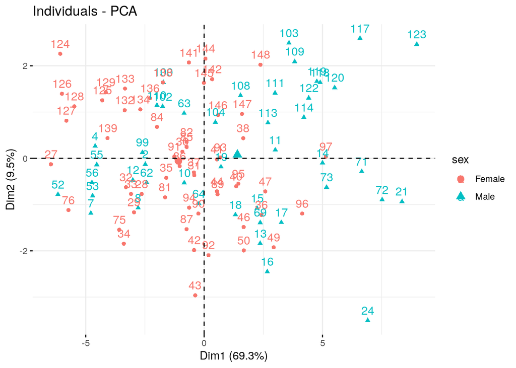

```r
mod_pca_sex <-
    df %>%
    select(sex, basilar.length:ramus.height) %>%
    PCA(graph= F, scale.unit = T, quali.sup = 1)

fviz_pca_ind(mod_pca_sex, habillage = 1)
```

Si, parece ser que la variable categórca `sex` queda realtivamente diferenciada en la dimension 1